# Practical Machine Learning Course Project - Prediction Assignment

## Background

Using devices such as Jawbone Up, Nike FuelBand, and Fitbit it is now possible to collect a large amount of data about personal activity relatively inexpensively. These type of devices are part of the quantified self movement - a group of enthusiasts who take measurements about themselves regularly to improve their health, to find patterns in their behavior, or because they are tech geeks. One thing that people regularly do is quantify how much of a particular activity they do, but they rarely quantify how well they do it. In this project, your goal will be to use data from accelerometers on the belt, forearm, arm, and dumbell of 6 participants. They were asked to perform barbell lifts correctly and incorrectly in 5 different ways. More information is available from the website here: http://groupware.les.inf.puc-rio.br/har (see the section on the Weight Lifting Exercise Dataset).

One thing that people regularly do is quantify how much of a particular activity they do, but they rarely quantify how well they do it. In this Write-up, our goal will be to use data from accelerometers on the belt, forearm, arm, and dumbell of 6 participants to predict the classes.

## Data Examination

Our first step will be loading the libraries and the data.

```r
library(caret)
library(randomForest)
```

```r
library(ggplot2)
library(corrplot)

setwd('C:\\Users\\User\\Desktop\\Certifications\\R\\Practical Machine Learning\\Assignment 4')

trainset <- read.csv("pml-training.csv", header = TRUE)
testset <- read.csv("pml-testing.csv", header = TRUE)
```

And then we can examine the data structures, variable names, etc.

```r
head(trainset)
```

```
##   X user_name raw_timestamp_part_1 raw_timestamp_part_2   cvtd_timestamp
## 1 1  carlitos           1323084231               788290 05/12/2011 11:23
## 2 2  carlitos           1323084231               808298 05/12/2011 11:23
## 3 3  carlitos           1323084231               820366 05/12/2011 11:23
## 4 4  carlitos           1323084232               120339 05/12/2011 11:23
## 5 5  carlitos           1323084232               196328 05/12/2011 11:23
## 6 6  carlitos           1323084232               304277 05/12/2011 11:23
##   new_window num_window roll_belt pitch_belt yaw_belt total_accel_belt
## 1         no         11      1.41       8.07    -94.4                3
## 2         no         11      1.41       8.07    -94.4                3
## 3         no         11      1.42       8.07    -94.4                3
## 4         no         12      1.48       8.05    -94.4                3
## 5         no         12      1.48       8.07    -94.4                3
## 6         no         12      1.45       8.06    -94.4                3
##   kurtosis_roll_belt kurtosis_picth_belt kurtosis_yaw_belt
```

[output cut: 265 more lines]

```r
names(trainset)
```

```
##   [1] "X"                        "user_name"
##   [3] "raw_timestamp_part_1"     "raw_timestamp_part_2"
##   [5] "cvtd_timestamp"           "new_window"
##   [7] "num_window"               "roll_belt"
##   [9] "pitch_belt"               "yaw_belt"
##  [11] "total_accel_belt"         "kurtosis_roll_belt"
##  [13] "kurtosis_picth_belt"      "kurtosis_yaw_belt"
##  [15] "skewness_roll_belt"       "skewness_roll_belt.1"
##  [17] "skewness_yaw_belt"        "max_roll_belt"
##  [19] "max_picth_belt"           "max_yaw_belt"
##  [21] "min_roll_belt"            "min_pitch_belt"
##  [23] "min_yaw_belt"             "amplitude_roll_belt"
##  [25] "amplitude_pitch_belt"     "amplitude_yaw_belt"
##  [27] "var_total_accel_belt"     "avg_roll_belt"
##  [29] "stddev_roll_belt"         "var_roll_belt"
```

[output cut: 65 more lines]

```r
dim(trainset)
```

```
## [1] 19622   160
```

```r
str(trainset)
```

```
## 'data.frame':    19622 obs. of  160 variables:
##  $ X                       : int  1 2 3 4 5 6 7 8 9 10 ...
##  $ user_name               : Factor w/ 6 levels "adelmo","carlitos",..: 2 2 2 2 2 2 2 2 2 2 ...
##  $ raw_timestamp_part_1    : int  1323084231 1323084231 1323084231 1323084232 1323084232 1323084232 1323084232 1323084232 1323084232 1323084232 ...
##  $ raw_timestamp_part_2    : int  788290 808298 820366 120339 196328 304277 368296 440390 484323 484434 ...
##  $ cvtd_timestamp          : Factor w/ 20 levels "02/12/2011 13:32",..: 9 9 9 9 9 9 9 9 9 9 ...
##  $ new_window              : Factor w/ 2 levels "no","yes": 1 1 1 1 1 1 1 1 1 1 ...
##  $ num_window              : int  11 11 11 12 12 12 12 12 12 12 ...
##  $ roll_belt               : num  1.41 1.41 1.42 1.48 1.48 1.45 1.42 1.42 1.43 1.45 ...
##  $ pitch_belt              : num  8.07 8.07 8.07 8.05 8.07 8.06 8.09 8.13 8.16 8.17 ...
##  $ yaw_belt                : num  -94.4 -94.4 -94.4 -94.4 -94.4 -94.4 -94.4 -94.4 -94.4 -94.4 ...
##  $ total_accel_belt        : int  3 3 3 3 3 3 3 3 3 3 ...
##  $ kurtosis_roll_belt      : Factor w/ 397 levels "","-0.016850",..: 1 1 1 1 1 1 1 1 1 1 ...
##  $ kurtosis_picth_belt     : Factor w/ 317 levels "","-0.021887",..: 1 1 1 1 1 1 1 1 1 1 ...
##  $ kurtosis_yaw_belt       : Factor w/ 2 levels "","#DIV/0!": 1 1 1 1 1 1 1 1 1 1 ...
```

[output cut: 86 more lines]

It shows there are 19622 observations out of 159 variables and 1 label.

We can also examine the label levels and its proportion.

```r
levels(trainset$classe)
```

```
## [1] "A" "B" "C" "D" "E"
```

```r
table(trainset$classe)
```

```
##
##    A    B    C    D    E
## 5580 3797 3422 3216 3607
```

```r
prop.table(table(trainset$classe))
```

```
##
##         A         B         C         D         E
## 0.2843747 0.1935073 0.1743961 0.1638977 0.1838243
```

it shows there are about 28% level “A” in the label, which is also the greatest one. But overall, it’s still quite evenly distributed, and we can call it a balanced data.

## Data pre-processing

Now we select variables whose name include specific terms and the label.

```r
filter = grepl("belt|arm|dumbbell|classe", names(trainset))
trainset = trainset[, filter]
testset = testset[, filter]
```

Next, We remove variables with all NA/Null value.

```r
is_data  <- apply(!is.na(trainset), 2, sum) > 19621
trainset <- trainset[, is_data]
testset  <- testset[, is_data]
```

Besides, we also examine whether variables with only single value exist and remove the vairiables with nzv = TRUE.

```r
zero.var = nearZeroVar(trainset, saveMetrics=TRUE)
trainset <- trainset[,-c(5:13,36:41,45:53,67:75)]
testset <- testset[,-c(5:13,36:41,45:53,67:75)]
```

We also need to set the seed and split data by 0.7 for cross validation.

```r
set.seed(1000)
DataPart <- createDataPartition(y=trainset$classe, p=0.70, list=FALSE)
train <- trainset[DataPart,]
valid <- trainset[-DataPart,]
```

## Variable selection

In this projct, we will use random forest algorithm to do the prediction. As a result, we use varImpPlot to the examine the importance of variables by the plot which shows the ability to variance explanations.

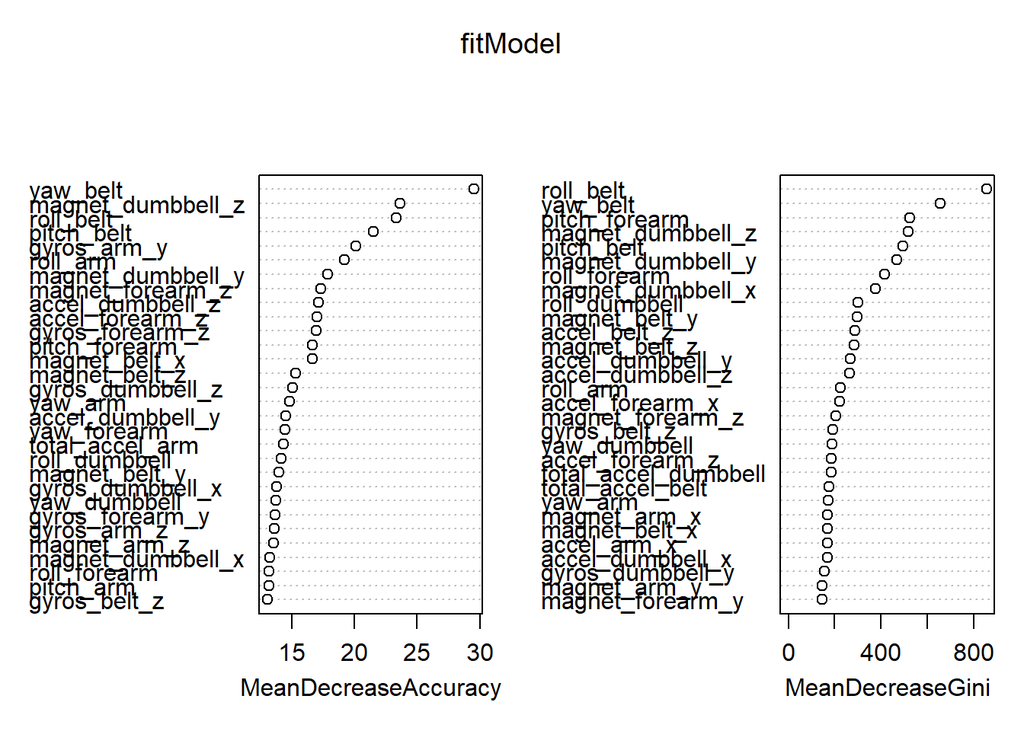

```r
fitModel <- randomForest(classe~., data=train, importance=TRUE, ntree=100)
varImpPlot(fitModel)
```

```r
correl = cor(train[,c("yaw_belt","pitch_belt","roll_belt","magnet_dumbbell_y","magnet_forearm_z","magnet_dumbbell_z","pitch_forearm","gyros_dumbbell_z","gyros_forearm_y","gyros_arm_y")])

diag(correl) <- 0
which(abs(correl)>0.75, arr.ind=TRUE)
```

```
##                  row col
## roll_belt          3   1
## yaw_belt           1   3
## gyros_forearm_y    9   8
## gyros_dumbbell_z   8   9
```

As what the result shows, there are over 75% correlation between “roll_belt”, “yaw_belt” and “gyros_forearm_y”, “gyros_dumbbell_z”.

```r
correl = cor(train[,c("yaw_belt","pitch_belt","magnet_dumbbell_y","magnet_forearm_z","magnet_dumbbell_z","pitch_forearm","gyros_dumbbell_z","gyros_arm_y","accel_dumbbell_y","gyros_forearm_x")])

diag(correl) <- 0
which(abs(correl)>0.75, arr.ind=TRUE)
```

```
##      row col
```

There is no significant correlated variables any more.

## Model Building and cross validation

Now we can build the model based on the variables listed above.

```r
bestfitmodel <- train(classe~yaw_belt+pitch_belt+magnet_dumbbell_y+magnet_forearm_z+magnet_dumbbell_z+pitch_forearm+gyros_dumbbell_z+gyros_arm_y+accel_dumbbell_y+gyros_forearm_x,
                      data=train,
                      method="rf",
                      trControl=trainControl(method="cv",number=2),
                      prox=TRUE,
                      verbose=TRUE,
                      allowParallel=TRUE)
```

We can also save the model for convenience.

```r
saveRDS(bestfitmodel, "modelRF.Rds")
bestfitmodel <- readRDS("modelRF.Rds")
```

Now we do the cross validation by predicting and examine the confusion Matrix of valid set.

```r
predictions <- predict(bestfitmodel, newdata=valid)
confusionMa <- confusionMatrix(predictions, valid$classe)
confusionMa
```

```
## Confusion Matrix and Statistics
##
##           Reference
## Prediction    A    B    C    D    E
##          A 1665    6    0    0    3
##          B    6 1126    7    0    5
##          C    1    6 1018    6    5
##          D    2    1    1  957    4
##          E    0    0    0    1 1065
##
## Overall Statistics
##
##                Accuracy : 0.9908
##                  95% CI : (0.988, 0.9931)
##     No Information Rate : 0.2845
##     P-Value [Acc > NIR] : < 2e-16
##
##                   Kappa : 0.9884
##  Mcnemar's Test P-Value : 0.01298
##
## Statistics by Class:
##
##                      Class: A Class: B Class: C Class: D Class: E
## Sensitivity            0.9946   0.9886   0.9922   0.9927   0.9843
## Specificity            0.9979   0.9962   0.9963   0.9984   0.9998
## Pos Pred Value         0.9946   0.9843   0.9826   0.9917   0.9991
## Neg Pred Value         0.9979   0.9973   0.9984   0.9986   0.9965
## Prevalence             0.2845   0.1935   0.1743   0.1638   0.1839
## Detection Rate         0.2829   0.1913   0.1730   0.1626   0.1810
## Detection Prevalence   0.2845   0.1944   0.1760   0.1640   0.1811
## Balanced Accuracy      0.9962   0.9924   0.9942   0.9956   0.9920
```

From the confusion Matrix, we can see that the accuracy is 99%, which is very high and the expected out of sample error rate = 1- 99% = 1%, which meet our anticipation which is less or equal to 1%.

## Final prediction

The below is the code of prediction to our test set:

```r
predictions <- predict(bestfitmodel, newdata=testset)
testset$classe <- predictions

submit <- data.frame(problem_id = testset$problem_id, classe = predictions)
write.csv(submit, file = "submission.csv", row.names = FALSE)
```

After submission, it shows 20/20 accuracy of prediction. We successfully predicted all 20 different cases.